# RepData_Project1

Marnel R

1/27/2021

## Loading and preprocessing the data

The first step is to download the file and load the data into R. First, prepare the dataframe by group (date) and then compute the summation of steps per date.

```r
library(knitr)
library(ggplot2)
library(tidyverse)
library(lubridate)
data <- read.csv('activity.csv')
data$date <- ymd(data$date)
```

## What is mean total number of steps taken per day?

The histogram will display the distribution of the total steps per day. The blue line displays the mean and the green dashed line for the median.

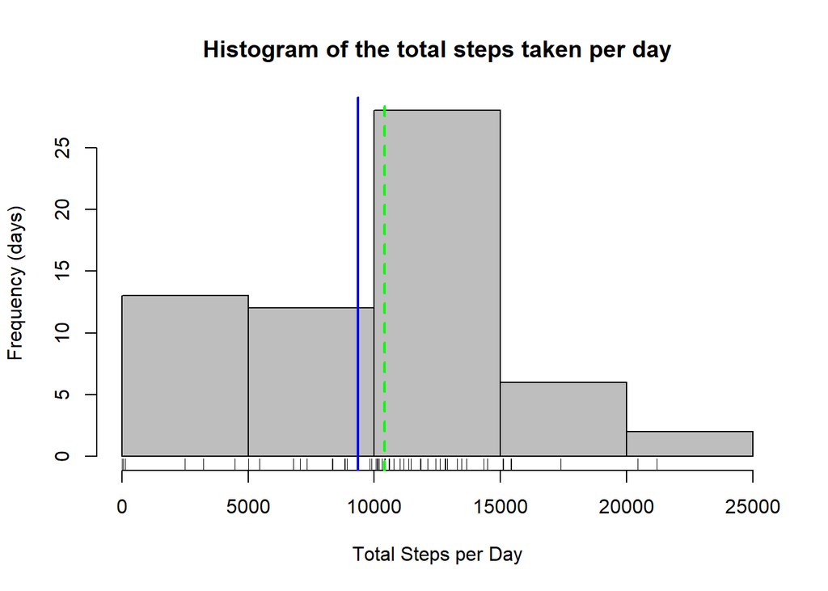

```r
#In this analysis, all the NAs under the step variable were considered in the succeeding computations.
steps_per_day <- with(data, aggregate(steps, by = list(date), sum, na.rm = TRUE))
names(steps_per_day) <- c("date", "steps")

hist(steps_per_day$steps, main = "Histogram of the total steps taken per day",
     xlab = "Total Steps per Day",
     ylab = "Frequency (days)",
     col = "gray")
rug(steps_per_day$steps)
abline(v=mean(steps_per_day$steps),lwd=2,col="blue")
abline(v=median(steps_per_day$steps),lwd=2,lty=2,col="green")
```

```r
#The mean and median are calculated and reported below.
mean(steps_per_day$steps)
```

```
## [1] 9354.23
```

```r
median(steps_per_day$steps)
```

```
## [1] 10395
```

## What is the average daily activity pattern?

A dataframe of the mean steps per interval is created and the NAs are discarded. The time-series plot is created to show the average steps per 5-minute interval.

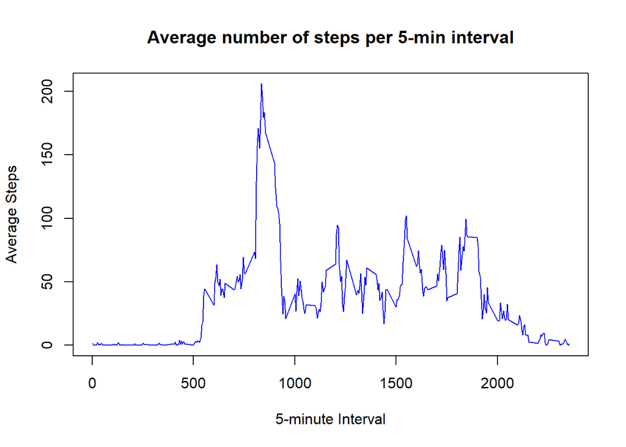

```r
mean_steps_interval <- aggregate(steps ~ interval, data, mean, na.rm = TRUE)
#A time-series plot is generated using the dataframe.
plot(mean_steps_interval$interval, mean_steps_interval$steps,
     type = "l",
     main = "Average number of steps per 5-min interval",
     xlab = "5-minute Interval",
     ylab = "Average Steps",
     col="blue")
```

```r
#The maximum number of average steps in the 5-minute interval is located in the interval below:
mean_steps_interval$interval[which.max(mean_steps_interval$steps)]
```

```
## [1] 835
```

## Imputing missing values

The series of codes below imputes NAs with the average steps per 5-minute interval. The dataset with imputed NAs compared to the original dataset vary as shown in the histogram below. The mean and median of the imputed data is higher.

```r
#The code blow calculates the total number of missing values in the dataset.
sum(is.na(data$steps))
```

```
## [1] 2304
```

```r
#This matches the mean of daily steps with the NAs.
imputed_steps <- mean_steps_interval$steps[match(data$interval, mean_steps_interval$interval)]
#Transforming steps in data if they were missing values with the filled values from above.
data_imputed <- transform(data, steps = ifelse(is.na(data$steps), yes = imputed_steps, no = data$steps))
# Forming the new dataset with the imputed missing values to create the mean steps per day.
total_data_imputed <- aggregate(steps ~ date, data_imputed, sum)
#The mean and median fo the imputed data are calculated and reported below.
mean(total_data_imputed$steps)
```

```
## [1] 10766.19
```

```r
median(total_data_imputed$steps)
```

```
## [1] 10766.19
```

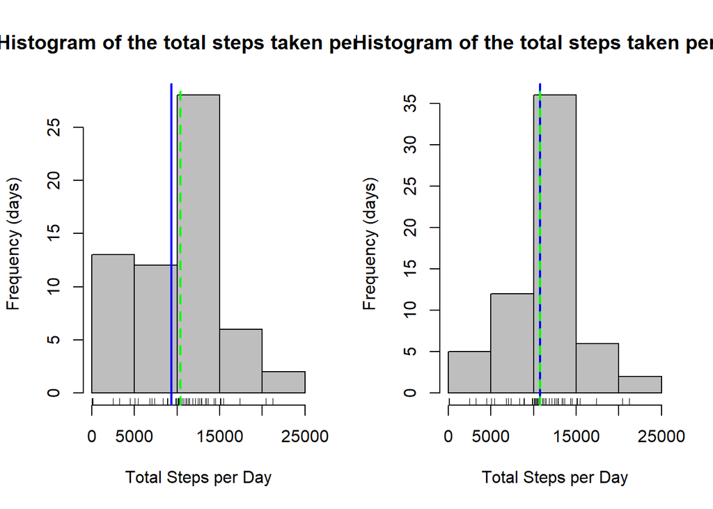

```r
#The plot below shows the impact of imputed NAs on the original data.
#The blue line displays the mean and the green dashed line for the median.

par(mfrow = c(1,2))
hist(steps_per_day$steps, main = "Histogram of the total steps taken per day",
     xlab = "Total Steps per Day",
     ylab = "Frequency (days)",
     col = "gray")
rug(steps_per_day$steps)
abline(v=mean(steps_per_day$steps),lwd=2,col="blue")
abline(v=median(steps_per_day$steps),lwd=2,lty=2,col="green")

hist(total_data_imputed$steps, main = "Histogram of the total steps taken per day",
     xlab = "Total Steps per Day",
     ylab = "Frequency (days)",
     col = "gray")
rug(total_data_imputed$steps)
abline(v=mean(total_data_imputed$steps),lwd=2,col="blue")
abline(v=median(total_data_imputed$steps),lwd=2,lty=2,col="green")
```

## Are there differences in activity patterns between weekdays and weekends?

A new factor variable is created to indicate whether the date is weekday or weekend. A comparative analysis of time-series plot is generated to show the average steps per 5-minute interval for weekday and weekend.

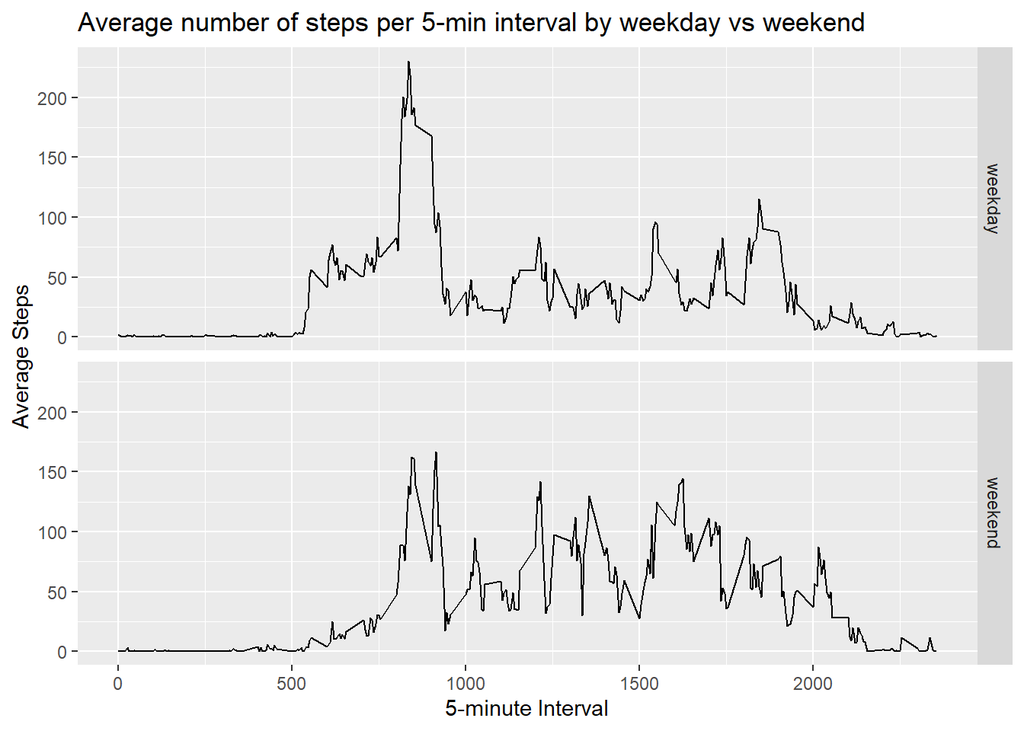

```r
day <- ifelse(weekdays(data_imputed$date) %in% c("Saturday", "Sunday"), "weekend", "weekday")
data_imputed$day <- as.factor(day)
#A panel plot is created containing a time series plot of the 5-minute interval and the average number of steps taken, averaged across all weekday days or weekend days.
mean_steps_interval_day <- aggregate(steps ~ day + interval, data_imputed, mean)

mean_steps_interval_day %>%
  ggplot(aes(interval, steps)) +
  facet_grid(day ~ .) +
  geom_line() +
  xlab("5-minute Interval")+
  ylab("Average Steps") +
  ggtitle("Average number of steps per 5-min interval by weekday vs weekend")
```